# Información espacial en formato raster en R

blog

Published

February 17, 2022

# Información espacial en formato ráster en R

Existen varios paquetes en R que permiten manejar datos espaciales, ya sea en formato de vector o raster. Algunos de ellos incluyen: `sp, rgdal, rgeos, sf, stars, raster, terra`. Sin embargo, en este curso nos enfocaremos en utilizar `sf` para el manejo de información vectorial y `stars` para el manejo de rasters.

# Introducción a stars

`stars` es un paquete creado para trabajar de manera sencilla con información raster y fue creado por el mismo grupo de trabajo que creo `sf`, así que muchas funciones y sintaxis son compartidas con dicho paquete.

## Rasters

El objeto básico en `stars` son los spatiotemporal arrays (stars), es decir arreglos espacio temporales. Recordemos que un arreglo corresponde a cualquier objeto organizado en dimensiones. Por ejemplo, una arreglo de dos dimensiones podría corresponder a una matriz que cuenta con una dimensión vertical (filas) y horizontal (columnas). De igual manera, un arreglo de tres dimensiones podría corresponder a una imagen raster con dos dimensiones espaciales (vertical y horizontal) y una dimensión espectral (bandas). Adicionalmente, un arreglo con cuatro dimensiones podría incluir una dimensión temporal.

Al igual que en `sf` cada raster va a estar asociado a un sistema de coordenadas de referencia (CRS). Por lo cual, dicho CRS indicará la proyección de los datos y el datum.

## Estructura de datos stars

Los datos stars van a estar organizados en un formato de `array`, es decir, de una tabla o cuadro de datos de n dimensiones. Para ver un ejemplos carguemos un archivo raster.

```r
library(stars)
tif = system.file("tif/L7_ETMs.tif", package = "stars")
x = read_stars(tif)
x
```

```
## stars object with 3 dimensions and 1 attribute
## attribute(s):
##              Min. 1st Qu. Median     Mean 3rd Qu. Max.
## L7_ETMs.tif     1      54     69 68.91242      86  255
## dimension(s):
##      from  to  offset delta                     refsys point values x/y
## x       1 349  288776  28.5 SIRGAS 2000 / UTM zone 25S FALSE   NULL [x]
## y       1 352 9120761 -28.5 SIRGAS 2000 / UTM zone 25S FALSE   NULL [y]
## band    1   6      NA    NA                         NA    NA   NULL
```

Analicemos qué dice esta información. Primero nos dice que se trata de un objeto stars de tres dimensiones y un atributo. Además, nos da algunas estadísticas de la información que contiene. A continuación, podemos ver las tres dimensiones: *x*, *y* y *band*, es decir, dos dimensiones espaciales y una espectral. Adicionalmente, se puede consultar el número de celdas en cada dimensión (from y to), la coordenada inicial en cada dimensión (offset), el tamaño de la celda en cada dimensión (delta), el sistema de referencia en el que se encuentra la información (refsys), si corresponde a puntos (point) y los valores de secuencia en caso de que la dimensión no sea regular (e.g., geometrías).

La misma información se puede consultar de manera más sintética.

```r
st_dimensions(x)
```

```
##      from  to  offset delta                     refsys point values x/y
## x       1 349  288776  28.5 SIRGAS 2000 / UTM zone 25S FALSE   NULL [x]
## y       1 352 9120761 -28.5 SIRGAS 2000 / UTM zone 25S FALSE   NULL [y]
## band    1   6      NA    NA                         NA    NA   NULL
```

## Lectura y escritura de datos

Para leer y escribir datos desde archivos externos se utilizan las funciones `read_stars` y `write_stars`. Por ejemplo, carguemos un archivo que viene en el paquete `stars`:

```r
filename <- system.file("tif/L7_ETMs.tif", package = "stars")
x <- read_stars(filename)
x
```

```
## stars object with 3 dimensions and 1 attribute
## attribute(s):
##              Min. 1st Qu. Median     Mean 3rd Qu. Max.
## L7_ETMs.tif     1      54     69 68.91242      86  255
## dimension(s):
##      from  to  offset delta                     refsys point values x/y
## x       1 349  288776  28.5 SIRGAS 2000 / UTM zone 25S FALSE   NULL [x]
## y       1 352 9120761 -28.5 SIRGAS 2000 / UTM zone 25S FALSE   NULL [y]
## band    1   6      NA    NA                         NA    NA   NULL
```

```r
write_stars(x,
         "x_exp.tif")
```

Por último, el visualizar los datos nos puede dar una muy buena idea de los productos intermedios en un flujo de trabajo o verificar que la información que importamos o exportamos es la correcta. Para ver el objecto stars con todos sus atributos:

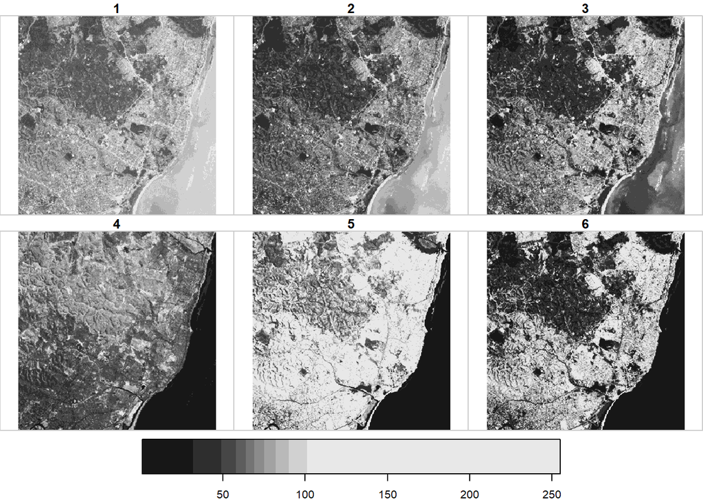

```r
plot(x)
```

También se puede hacer un RGB en color natural o falso color.

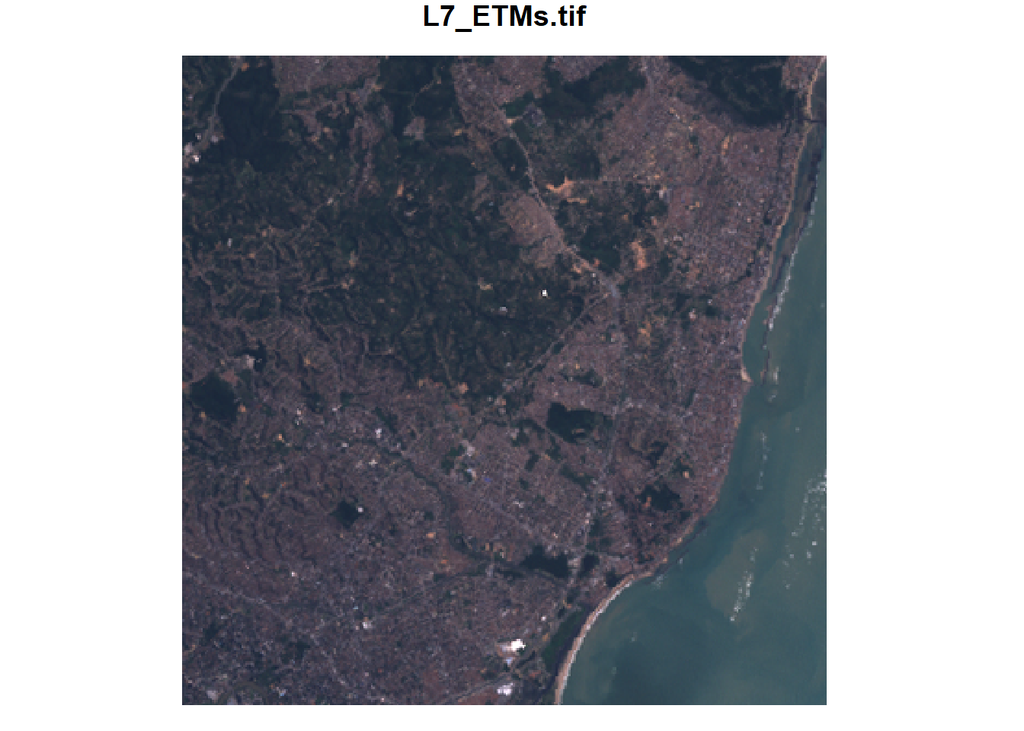

```r
plot(x,
     rgb = c(3,2,1))
```

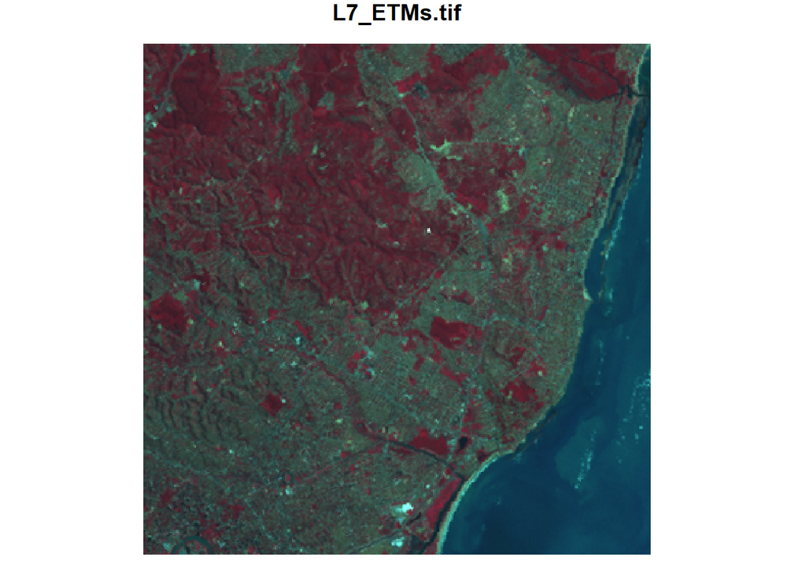

```r
plot(x,
     rgb = c(4,3,2))
```

## Descargar información de trabajo

Primero vamos a cargar información desde mi github.

```
## [1] "D:\\Drive\\Jonathan_trabaggio\\Doctorado\\R\\SIG\\Curso\\Data\\Sentinel2-2A_10B_2020-01-01_2020-12-30.tif"
## [2] "D:\\Drive\\Jonathan_trabaggio\\Doctorado\\R\\SIG\\Curso\\Data\\SRTM_area.tif"
## [3] "D:\\Drive\\Jonathan_trabaggio\\Doctorado\\R\\SIG\\Curso\\Data\\roi.zip"
```

Veamos qué descargamos.

```r
im1 <- read_stars(paste0(getwd(), "/Data/", "Sentinel2-2A_10B_2020-01-01_2020-12-30.tif"))

im1
```

```
## stars object with 3 dimensions and 1 attribute
## attribute(s):
##                                    Min. 1st Qu. Median     Mean 3rd Qu. Max.
## Sentinel2-2A_10B_2020-01-01_20...     6     913   1552 1501.178 2010.75 5041
## dimension(s):
##      from  to   offset        delta refsys point     values x/y
## x       1 103 -101.235  0.000179663 WGS 84 FALSE       NULL [x]
## y       1  81  19.6582 -0.000179663 WGS 84 FALSE       NULL [y]
## band    1  10       NA           NA     NA    NA B2,...,B12
```

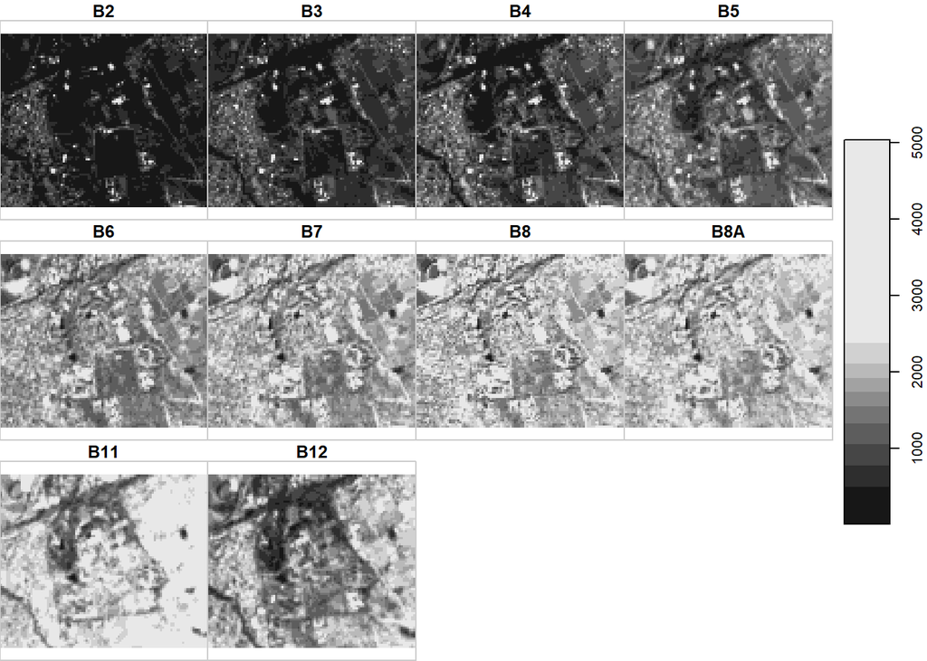

```r
plot(im1)
```

# Operaciones básicas

## Elegir parte basado en los índices de los objetos stars

Para elegir parte de los rasters, se puede hacerlo eligiendo parte del arreglo. Esto se puede hacer utilizando la notación tradicional de objetos stars o usando la forma tidyverse-esque.

```r
im1[,1:10,1:20]
```

```
## stars object with 3 dimensions and 1 attribute
## attribute(s):
##                                    Min. 1st Qu. Median     Mean 3rd Qu. Max.
## Sentinel2-2A_10B_2020-01-01_20...    73  691.25   1149 1315.034 1693.25 5041
## dimension(s):
##      from to   offset        delta refsys point     values x/y
## x       1 10 -101.235  0.000179663 WGS 84 FALSE       NULL [x]
## y       1 20  19.6582 -0.000179663 WGS 84 FALSE       NULL [y]
## band    1 10       NA           NA     NA    NA B2,...,B12
```

```r
im1_sub1 <- im1[,1:10,1:20, 2]
im1_sub1
```

```
## stars object with 3 dimensions and 1 attribute
## attribute(s):
##                                    Min. 1st Qu. Median   Mean 3rd Qu. Max.
## Sentinel2-2A_10B_2020-01-01_20...   189  485.75  556.5 555.88     635  889
## dimension(s):
##      from to   offset        delta refsys point values x/y
## x       1 10 -101.235  0.000179663 WGS 84 FALSE   NULL [x]
## y       1 20  19.6582 -0.000179663 WGS 84 FALSE   NULL [y]
## band    2  2       NA           NA     NA    NA     B3
```

```r
library(tidyverse)
im1_sub2 <- im1 |>
  slice(x, 1:10) |>
  slice(y, 1:20) |>
  slice(band, 2)
im1_sub2
```

```
## stars object with 2 dimensions and 1 attribute
## attribute(s):
##                                    Min. 1st Qu. Median   Mean 3rd Qu. Max.
## Sentinel2-2A_10B_2020-01-01_20...   189  485.75  556.5 555.88     635  889
## dimension(s):
##   from to   offset        delta refsys point values x/y
## x    1 10 -101.235  0.000179663 WGS 84 FALSE   NULL [x]
## y    1 20  19.6582 -0.000179663 WGS 84 FALSE   NULL [y]
```

## Elegir parte basado en los valores de los objetos stars

Además podríamos estar interesados en filtrar valores de los rasters en función de los valores de cierta banda. Para ello, podemos hacer la función `filter`.

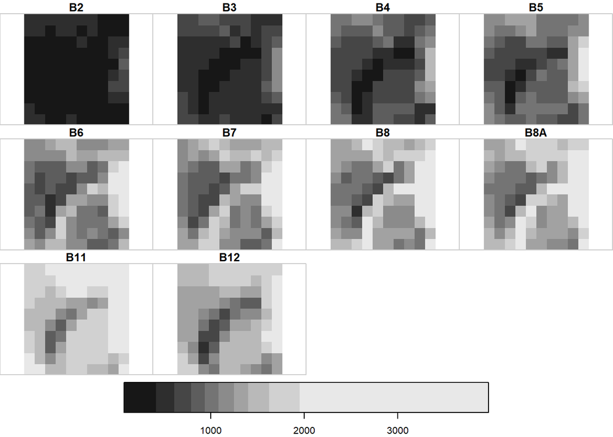

```r
library(cubelyr)
im1_sub3 <- im1 |>
  filter(x < -101.2332, x > -101.235,
         y > 19.6564, y < 19.6582,
         band > 3 )
plot(im1_sub3)
```

## Elegir parte basado en un vector

Para seleccionar parte de un raster basado en un vector se puede utilizar la notación tradicional de corchetes `[]` o la función `st_crop`.

```r
roi <- st_read(paste0(getwd(), "/Data/", "roi.shp"))
```

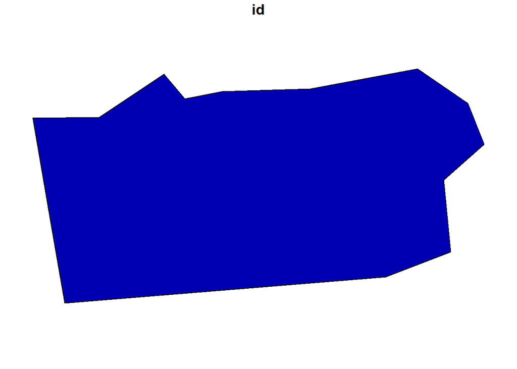

```r
plot(roi)
```

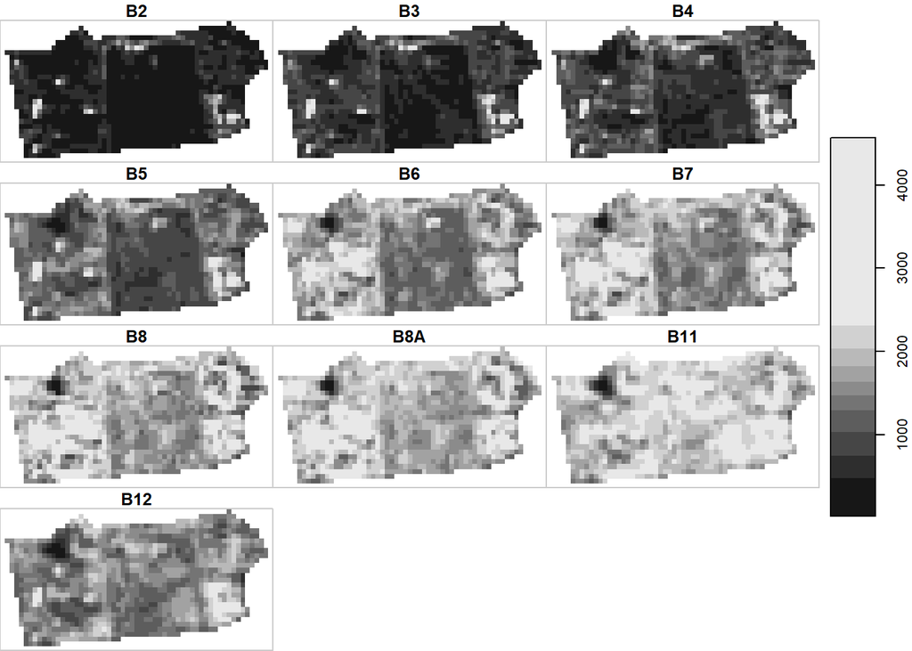

```r
im1_crop <- im1[roi]
plot(im1_crop)
```

```r
im1_crop2 <- st_crop(im1,
                     roi)
plot(im1_crop2)
```

[output not shown]

## Extraer parte de los objetos stars

Para extraer los valores del objeto stars y convertirlos a arreglos se puede usar la función `pull`. Usando esta función se extrae el atributo indicado dentro de `pull`.

```r
im_pull <- im1 |>
  pull(1)
# Mostrar únicamente el encabezado y algunos datos de muestra
head(im_pull)
```

```
## , , 1
##
##      [,1] [,2] [,3] [,4] [,5] [,6] [,7] [,8] [,9] [,10] [,11] [,12] [,13] [,14]
## [1,]  434  482  414  401  414  415  386  333  200   205   227   264   259   317
## [2,]  434  482  441  398  401  411  440  513  533   478   372   398   397   411
## [3,]  443  487  400  354  339  337  371  399  479   494   462   490   444   367
## [4,]  488  441  326  309  325  333  359  324  390   511   501   489   463   393
## [5,]  560  409  309  320  314  244  114   84  104   303   466   538   402   367
## [6,]  594  418  321  306  255   73  134  225  296   300   208   453   471   275
##      [,15] [,16] [,17] [,18] [,19] [,20] [,21] [,22] [,23] [,24] [,25] [,26]
## [1,]   155   316   402   424   426   434   422   403   369   367   189   456
## [2,]   244   224   357   419   382   398   420   392   350   346   270   408
## [3,]   192   171   257   422   478   415   394   347   336   268   459   251
## [4,]   149   153   160   343   456   465   397   320   219   193   247   109
## [5,]   130   133   136   292   416   447   435   372   171   211   155   125
```

[output cut: 504 more lines]

## Agregar un nuevo atributo

Para agregar un nuevo atributo en función de los que ya existen.

```r
names(im1) <- "Sentinel2"
im2 <- im1 |>
  mutate(band2 = 2 * Sentinel2)
im2
```

```
## stars object with 3 dimensions and 2 attributes
## attribute(s):
##            Min. 1st Qu. Median     Mean 3rd Qu.  Max.
## Sentinel2     6     913   1552 1501.178 2010.75  5041
## band2        12    1826   3104 3002.356 4021.50 10082
## dimension(s):
##      from  to   offset        delta refsys point     values x/y
## x       1 103 -101.235  0.000179663 WGS 84 FALSE       NULL [x]
## y       1  81  19.6582 -0.000179663 WGS 84 FALSE       NULL [y]
## band    1  10       NA           NA     NA    NA B2,...,B12
```

Ahora ya tenemos dos atributos.

## Para seleccionar ciertos atributos

Para seleccionar algunos atributos se usa `select`.

```r
im2 |>
  select(band2)
```

```
## stars object with 3 dimensions and 1 attribute
## attribute(s):
##        Min. 1st Qu. Median     Mean 3rd Qu.  Max.
## band2    12    1826   3104 3002.356  4021.5 10082
## dimension(s):
##      from  to   offset        delta refsys point     values x/y
## x       1 103 -101.235  0.000179663 WGS 84 FALSE       NULL [x]
## y       1  81  19.6582 -0.000179663 WGS 84 FALSE       NULL [y]
## band    1  10       NA           NA     NA    NA B2,...,B12
```

## Cálculo de índices

En algunos casos estaremos más interesados en calcular índices que resalten algunas características de la superficie terrestre. Por ejemplo, algún índice de vegetación. Esto se puede realizar al seleccionar las bandas de interés y aplicar la fórmula.

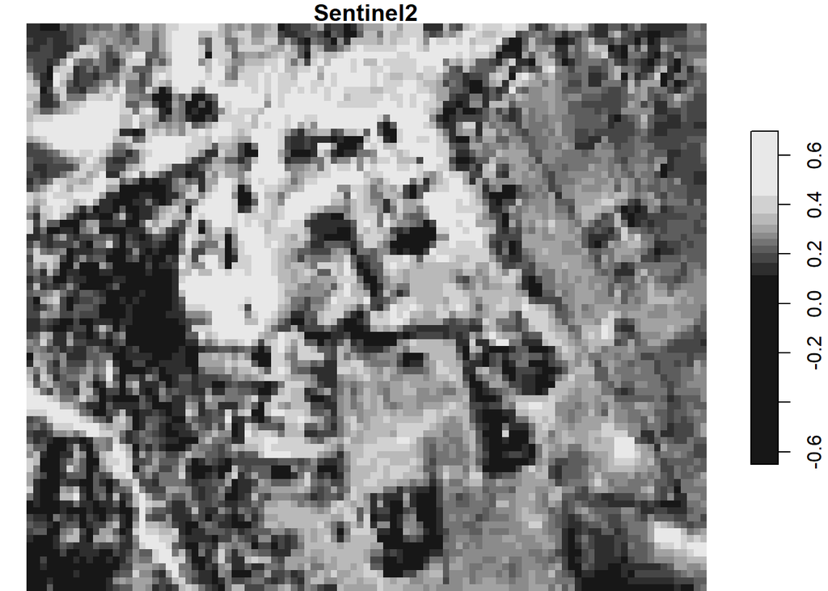

```r
NIR <- im1[,,,8]
R <- im1 [,,,4]

# Tidyverse-esque
# Si no se agrega drop = F, se elimina la tercera dimensión y luego ya no permite concatenar esta banda con el resto de la imagen.
NIR <- im1 |>
  slice(band, 8, drop = F)
R <- im1 |>
  slice(band, 4, drop = F)

NDVI <- (NIR - R) / (NIR + R)

plot(NDVI)
```

## Agregar bandas a un raster

Para agregar una banda a un raster se utiliza la función `c`.

```r
im1_cNDVI <- c(im1,
               NDVI,
               along = 3)
```

# Transformaciones de formato

Para transformar un vector a raster se utiliza la función `st_rasterize`. Para ello, hay que determinar la resolución a la que se quiere rasterizar esta información. Utilizamos los valores de resolución que tiene el objeto im1. Recordemos que estos valores están en las unidades del CRS de la capa. En este caso, el CRS está en coordenadas geográficas, por eso se utilizarán valores en grados.

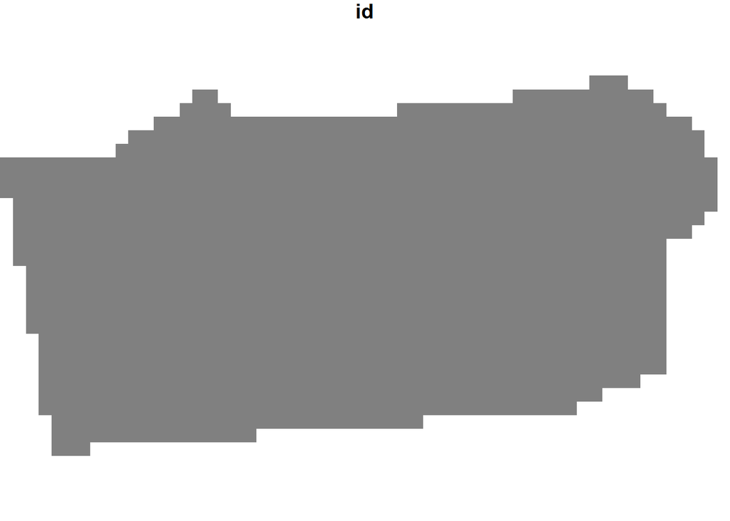

```r
roi_rast <- st_rasterize(roi["id"], dx = 0.000179663, dy = -0.000179663)
plot(roi_rast)
```

## Transformación de raster a vector

Para transformar de raster a un vector de puntos se puede utilizar la función `st_as_sf`, utilizando el argumento de `as_points`. Además, si se desean obtener los datos en formato largo en lugar de ancho se puede utilizar el argumento `long`.

```r
st_as_sf(im1,
         as_points = TRUE,
         merge = FALSE)
```

```
## Simple feature collection with 8343 features and 10 fields
## Geometry type: POINT
## Dimension:     XY
## Bounding box:  xmin: -101.2352 ymin: 19.64373 xmax: -101.2169 ymax: 19.6581
## Geodetic CRS:  WGS 84
## First 10 features:
##     B2  B3   B4   B5   B6   B7   B8  B8A  B11  B12                  geometry
## 1  434 662  939 1078 1200 1246 1318 1412 1909 1480 POINT (-101.2352 19.6581)
## 2  434 662  939 1078 1200 1246 1318 1412 1909 1480  POINT (-101.235 19.6581)
## 3  443 685  960 1096 1179 1244 1327 1372 1856 1469 POINT (-101.2348 19.6581)
## 4  488 729 1028 1168 1237 1314 1386 1380 1908 1483 POINT (-101.2347 19.6581)
## 5  560 803 1091 1271 1313 1423 1504 1588 2054 1602 POINT (-101.2345 19.6581)
## 6  594 889 1203 1345 1624 1863 2108 2062 2588 1925 POINT (-101.2343 19.6581)
## 7  461 693  980 1257 1480 1604 1709 1862 2636 1926 POINT (-101.2341 19.6581)
## 8  420 645  907 1067 1152 1321 1561 1701 2432 1814 POINT (-101.2339 19.6581)
## 9  436 635  920 1047 1187 1349 1544 1679 2429 1796 POINT (-101.2338 19.6581)
## 10 345 528  745  990 1185 1381 1333 1621 2329 1695 POINT (-101.2336 19.6581)
```

Utilizando la misma función se puede convertir de raster a vector de polígonos. En este caso, se indica como argumentos que no se desea obtener una capa de puntos y en `merge` se puede indicar si se desea fusionar los polígonos con un mismo valor o no.

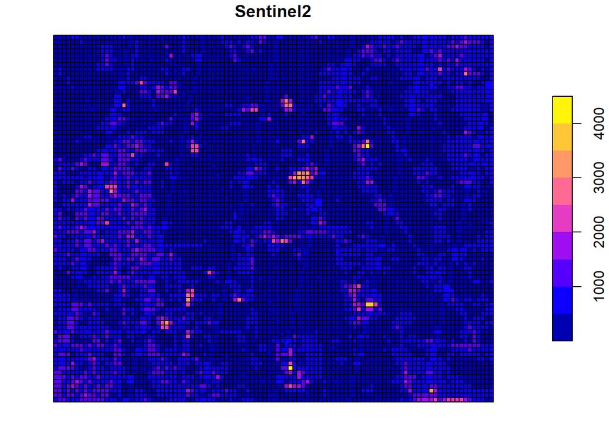

```r
im1_poly <- st_as_sf(im1,
                     as_points = F,
                     merge = T)
plot(im1_poly)
```

# Operaciones espaciales

## Reproyección de rasters

Para reproyectar un raster se utiliza la función `st_transform`. Al igual que en `sf` se necesita indicar el CRS objetivo ya sea mediante el código EPSG o obteniendo dicha clave con `st_crs`. Este tipo de reproyección no presenta pérdida de información debido a las diferencias entre proyecciones. Por lo tanto, los pixeles pueden no ser de dimensiones homogeneas en toda la imagen. Ve la siguiente función para hacer reproyecciones más clásicas.

```r
im1_utm <- st_transform(im1,
                        32614)
im1_utm
```

```
## stars object with 3 dimensions and 1 attribute
## attribute(s):
##            Min. 1st Qu. Median     Mean 3rd Qu. Max.
## Sentinel2     6     913   1552 1501.178 2010.75 5041
## dimension(s):
##      from  to offset delta                refsys point
## x       1 103     NA    NA WGS 84 / UTM zone 14N FALSE
## y       1  81     NA    NA WGS 84 / UTM zone 14N FALSE
## band    1  10     NA    NA                    NA    NA
##                            values x/y
## x      [103x81] 265619,...,267562 [x]
## y    [103x81] 2173570,...,2175186 [y]
## band                   B2,...,B12
## curvilinear grid
```

## Resampling

```r
im1_utm_20m <- st_warp(im1,
                       crs = st_crs(im1),
                       cellsize = c(20, 20))
im1_utm_20m
```

```
## stars object with 3 dimensions and 1 attribute
## attribute(s):
##            Min. 1st Qu. Median Mean 3rd Qu. Max. NA's
## Sentinel2    NA      NA     NA  NaN      NA   NA   10
## dimension(s):
##      from to   offset delta refsys point     values x/y
## x       1  1 -101.235    20 WGS 84    NA       NULL [x]
## y       1  1  19.6582   -20 WGS 84    NA       NULL [y]
## band    1 10       NA    NA     NA    NA B2,...,B12
```

## Crear mosaicos a partir de varios rasters

Para crear un mosaico a partir de dos o más imágenes se utiliza la función `st_mosaic`.

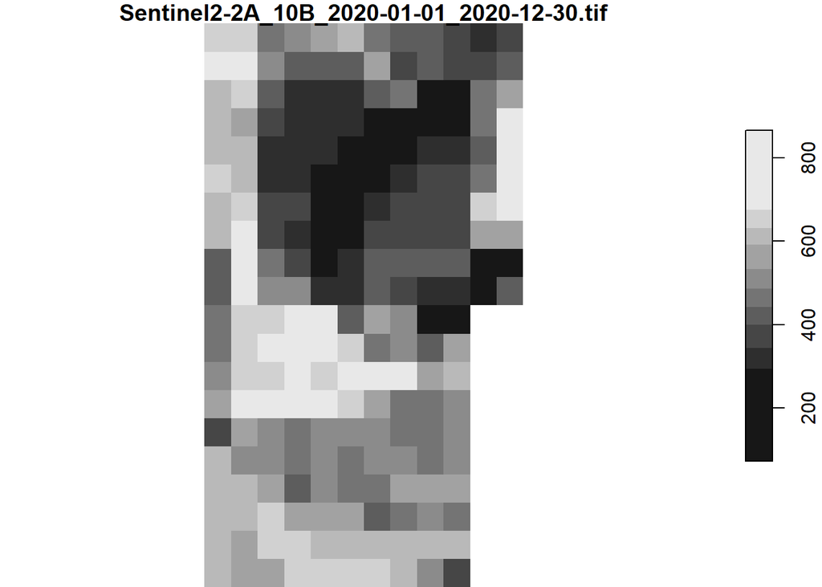

```r
im_mosaic <- st_mosaic(im1_sub2, im1_sub3)
plot(im_mosaic)
```

# Operaciones basadas en los valores de raster

## Reclasificar

Para reclasificar un raster se puede realizar con la función `cut`, indicando los intervalos para las clases.

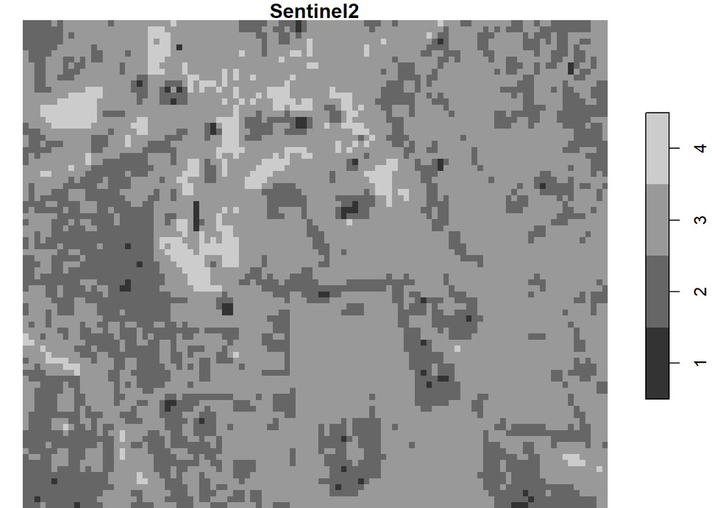

```r
reclass_NDVI <- cut(NDVI,
    breaks = c(-1, 0, 0.2, 0.5, 1),
    labels = F)
plot(reclass_NDVI)
```

## Enmascarar

Para enmascarar algún raster utilizando otro. De igual manera se pueden emascarar los valores que no cumplan con algún criterio de interés.

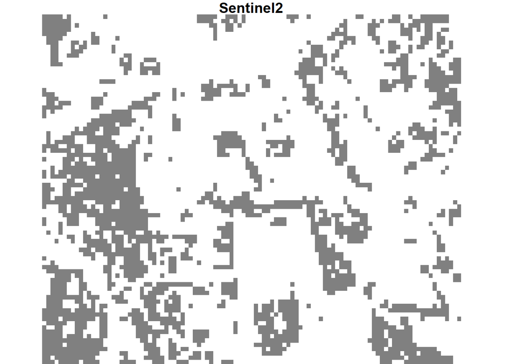

```r
im_mask <- reclass_NDVI
im_mask[im_mask != 2] <- NA

reclass_NDVI2 <- reclass_NDVI
reclass_NDVI2[is.na(im_mask)] <- NA
plot(reclass_NDVI2)
```